# PA1_template

Matt Wynn

2022-08-28

## Loading and preprocessing the data

This chunk downloads and loads the data, and formats the date.

```r
wd_path <- getwd()
url <- "http://d396qusza40orc.cloudfront.net/repdata%2Fdata%2Factivity.zip"
download.file(url, destfile = 'C5W2Ass-1.zip', method = 'curl')
unzip(zipfile = "C5W2Ass-1.zip")
datRaw <- read.csv("activity.csv")
datRaw$Date <- as.Date(datRaw$date, "%Y-%m-%d") #adds date column in date format
```

## What is mean total number of steps taken per day?

### Note: Missing data is ignored

1. Calculate total number of steps taken per day.

```r
total_steps_per_day <- tapply(datRaw$steps, datRaw$Date, sum)
total_steps_per_day
```

```
## 2012-10-01 2012-10-02 2012-10-03 2012-10-04 2012-10-05 2012-10-06 2012-10-07
##         NA        126      11352      12116      13294      15420      11015
## 2012-10-08 2012-10-09 2012-10-10 2012-10-11 2012-10-12 2012-10-13 2012-10-14
##         NA      12811       9900      10304      17382      12426      15098
## 2012-10-15 2012-10-16 2012-10-17 2012-10-18 2012-10-19 2012-10-20 2012-10-21
##      10139      15084      13452      10056      11829      10395       8821
## 2012-10-22 2012-10-23 2012-10-24 2012-10-25 2012-10-26 2012-10-27 2012-10-28
##      13460       8918       8355       2492       6778      10119      11458
## 2012-10-29 2012-10-30 2012-10-31 2012-11-01 2012-11-02 2012-11-03 2012-11-04
##       5018       9819      15414         NA      10600      10571         NA
## 2012-11-05 2012-11-06 2012-11-07 2012-11-08 2012-11-09 2012-11-10 2012-11-11
##      10439       8334      12883       3219         NA         NA      12608
## 2012-11-12 2012-11-13 2012-11-14 2012-11-15 2012-11-16 2012-11-17 2012-11-18
##      10765       7336         NA         41       5441      14339      15110
## 2012-11-19 2012-11-20 2012-11-21 2012-11-22 2012-11-23 2012-11-24 2012-11-25
##       8841       4472      12787      20427      21194      14478      11834
## 2012-11-26 2012-11-27 2012-11-28 2012-11-29 2012-11-30
##      11162      13646      10183       7047         NA
```

2. Make a histogram of the total number of steps taken each day.

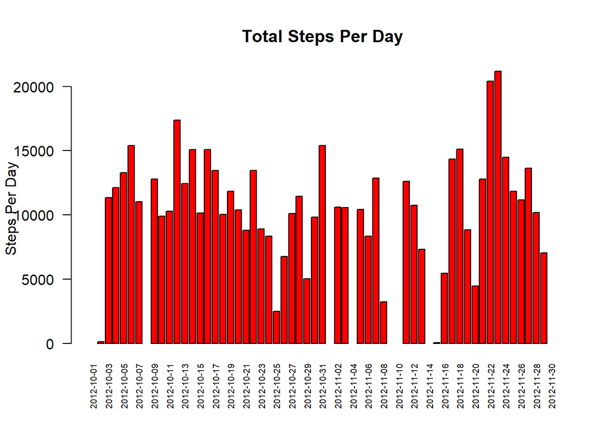

```r
barplot(total_steps_per_day, las=2, cex.names = .6, col = "red", ylab = "Steps Per Day",
        main = "Total Steps Per Day")
```

3. Calculate the mean and median of the total number of steps taken per day.

```r
datMean <- tapply(datRaw$steps, datRaw$Date, mean)
datMedian <- tapply(datRaw$steps, datRaw$Date, median)
datMeanMedian <- rbind(datMean, datMedian)
datMeanMedian
```

```
##           2012-10-01 2012-10-02 2012-10-03 2012-10-04 2012-10-05 2012-10-06
## datMean           NA     0.4375   39.41667   42.06944   46.15972   53.54167
## datMedian         NA     0.0000    0.00000    0.00000    0.00000    0.00000
##           2012-10-07 2012-10-08 2012-10-09 2012-10-10 2012-10-11 2012-10-12
## datMean     38.24653         NA   44.48264     34.375   35.77778   60.35417
## datMedian    0.00000         NA    0.00000      0.000    0.00000    0.00000
##           2012-10-13 2012-10-14 2012-10-15 2012-10-16 2012-10-17 2012-10-18
## datMean     43.14583   52.42361   35.20486     52.375   46.70833   34.91667
## datMedian    0.00000    0.00000    0.00000      0.000    0.00000    0.00000
##           2012-10-19 2012-10-20 2012-10-21 2012-10-22 2012-10-23 2012-10-24
## datMean     41.07292   36.09375   30.62847   46.73611   30.96528   29.01042
## datMedian    0.00000    0.00000    0.00000    0.00000    0.00000    0.00000
##           2012-10-25 2012-10-26 2012-10-27 2012-10-28 2012-10-29 2012-10-30
## datMean     8.652778   23.53472   35.13542   39.78472   17.42361   34.09375
## datMedian   0.000000    0.00000    0.00000    0.00000    0.00000    0.00000
##           2012-10-31 2012-11-01 2012-11-02 2012-11-03 2012-11-04 2012-11-05
## datMean     53.52083         NA   36.80556   36.70486         NA   36.24653
## datMedian    0.00000         NA    0.00000    0.00000         NA    0.00000
##           2012-11-06 2012-11-07 2012-11-08 2012-11-09 2012-11-10 2012-11-11
## datMean      28.9375   44.73264   11.17708         NA         NA   43.77778
## datMedian     0.0000    0.00000    0.00000         NA         NA    0.00000
##           2012-11-12 2012-11-13 2012-11-14 2012-11-15 2012-11-16 2012-11-17
## datMean     37.37847   25.47222         NA  0.1423611   18.89236   49.78819
## datMedian    0.00000    0.00000         NA  0.0000000    0.00000    0.00000
##           2012-11-18 2012-11-19 2012-11-20 2012-11-21 2012-11-22 2012-11-23
## datMean     52.46528   30.69792   15.52778   44.39931   70.92708   73.59028
## datMedian    0.00000    0.00000    0.00000    0.00000    0.00000    0.00000
##           2012-11-24 2012-11-25 2012-11-26 2012-11-27 2012-11-28 2012-11-29
## datMean     50.27083   41.09028   38.75694   47.38194   35.35764   24.46875
## datMedian    0.00000    0.00000    0.00000    0.00000    0.00000    0.00000
##           2012-11-30
## datMean           NA
## datMedian         NA
```

## What is the average daily activity pattern?

1. Make a time series plot of the 5-minute interval (x-axis) and the average number of steps taken, averaged across all days (y-axis)

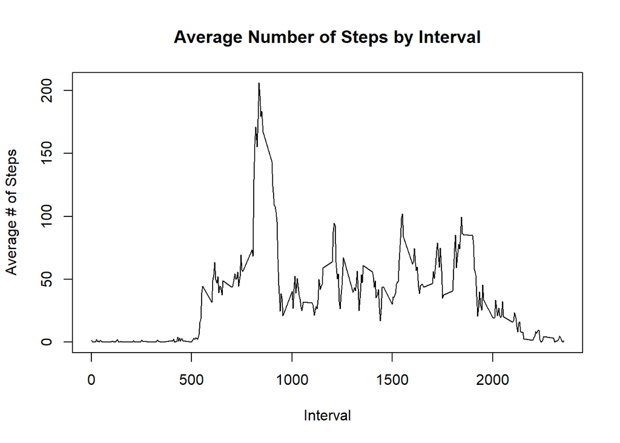

```r
datAvgByInterval = datRaw %>% group_by(interval) %>%
  summarise(Avg_by_interval = mean(steps, na.rm=TRUE), .groups = 'drop')
plot(datAvgByInterval, type = 'l', xlab = "Interval", ylab = "Average # of Steps", main = "Average Number of Steps by Interval")
```

2. Which 5-minute interval, on average across all the days of the data set, contains the maximum number of steps?

```r
#datAvgByInterval[,which.max(datAvgByInterval$Avg_by_interval)]
highestInterval <- datAvgByInterval[which.max(datAvgByInterval$Avg_by_interval), ]
highestInterval2 <- as.data.frame(highestInterval[,1])
highestInterval2
```

```
##   interval
## 1      835
```

## Imputing Missing Values

1. Calculate and report the total number of missing values in the data set.

```r
datMissing <- datRaw[is.na(datRaw$steps), ]
nrow(datMissing)
```

```
## [1] 2304
```

2. Devise a strategy for filling in all of the missing values in the dataset. This program will use mean value of steps across the dataset.
3. Create a new dataset that is equal to the original dataset but with the missing data filled in.

```r
datFilled <- datRaw
datFilled$steps[is.na(datFilled$steps)] <- mean(datFilled$steps, na.rm=TRUE)
```

4. Make a histogram of the total number of steps taken each day and calculate and report the mean and median total number of steps taken per day. Do these values differ from the estimates from the first part of the assignment? What is the impact of imputing missing data on the estimates of the total daily number of steps?

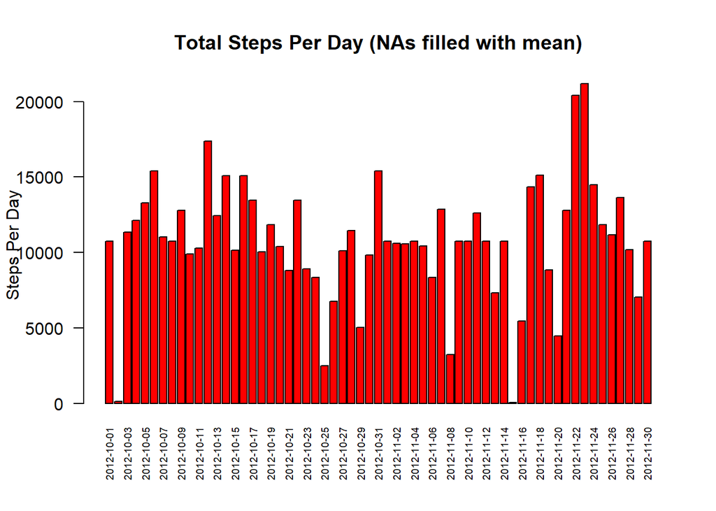

```r
total_steps_per_day_filled <- tapply(datFilled$steps, datFilled$Date, sum)
barplot(total_steps_per_day_filled, las=2, cex.names = .6, col = "red",
        ylab = "Steps Per Day", main = "Total Steps Per Day (NAs filled with mean)")
```

```r
datMeanFilled <- tapply(datFilled$steps, datFilled$Date, mean)
datMedianFilled <- tapply(datFilled$steps, datFilled$Date, median)
datMeanMedianFilled <- rbind(datMeanFilled, datMedianFilled)
datMeanMedianCombined <- rbind(datMeanMedian, datMeanMedianFilled)
datMeanMedianCombined
```

```
##                 2012-10-01 2012-10-02 2012-10-03 2012-10-04 2012-10-05
## datMean                 NA     0.4375   39.41667   42.06944   46.15972
## datMedian               NA     0.0000    0.00000    0.00000    0.00000
## datMeanFilled      37.3826     0.4375   39.41667   42.06944   46.15972
## datMedianFilled    37.3826     0.0000    0.00000    0.00000    0.00000
##                 2012-10-06 2012-10-07 2012-10-08 2012-10-09 2012-10-10
## datMean           53.54167   38.24653         NA   44.48264     34.375
## datMedian          0.00000    0.00000         NA    0.00000      0.000
## datMeanFilled     53.54167   38.24653    37.3826   44.48264     34.375
## datMedianFilled    0.00000    0.00000    37.3826    0.00000      0.000
##                 2012-10-11 2012-10-12 2012-10-13 2012-10-14 2012-10-15
## datMean           35.77778   60.35417   43.14583   52.42361   35.20486
## datMedian          0.00000    0.00000    0.00000    0.00000    0.00000
## datMeanFilled     35.77778   60.35417   43.14583   52.42361   35.20486
## datMedianFilled    0.00000    0.00000    0.00000    0.00000    0.00000
##                 2012-10-16 2012-10-17 2012-10-18 2012-10-19 2012-10-20
## datMean             52.375   46.70833   34.91667   41.07292   36.09375
## datMedian            0.000    0.00000    0.00000    0.00000    0.00000
## datMeanFilled       52.375   46.70833   34.91667   41.07292   36.09375
## datMedianFilled      0.000    0.00000    0.00000    0.00000    0.00000
##                 2012-10-21 2012-10-22 2012-10-23 2012-10-24 2012-10-25
## datMean           30.62847   46.73611   30.96528   29.01042   8.652778
## datMedian          0.00000    0.00000    0.00000    0.00000   0.000000
## datMeanFilled     30.62847   46.73611   30.96528   29.01042   8.652778
## datMedianFilled    0.00000    0.00000    0.00000    0.00000   0.000000
##                 2012-10-26 2012-10-27 2012-10-28 2012-10-29 2012-10-30
## datMean           23.53472   35.13542   39.78472   17.42361   34.09375
## datMedian          0.00000    0.00000    0.00000    0.00000    0.00000
## datMeanFilled     23.53472   35.13542   39.78472   17.42361   34.09375
## datMedianFilled    0.00000    0.00000    0.00000    0.00000    0.00000
##                 2012-10-31 2012-11-01 2012-11-02 2012-11-03 2012-11-04
## datMean           53.52083         NA   36.80556   36.70486         NA
## datMedian          0.00000         NA    0.00000    0.00000         NA
## datMeanFilled     53.52083    37.3826   36.80556   36.70486    37.3826
## datMedianFilled    0.00000    37.3826    0.00000    0.00000    37.3826
##                 2012-11-05 2012-11-06 2012-11-07 2012-11-08 2012-11-09
## datMean           36.24653    28.9375   44.73264   11.17708         NA
## datMedian          0.00000     0.0000    0.00000    0.00000         NA
## datMeanFilled     36.24653    28.9375   44.73264   11.17708    37.3826
## datMedianFilled    0.00000     0.0000    0.00000    0.00000    37.3826
```

[output cut: 10 more lines]

```
##                 2012-11-20 2012-11-21 2012-11-22 2012-11-23 2012-11-24
## datMean           15.52778   44.39931   70.92708   73.59028   50.27083
## datMedian          0.00000    0.00000    0.00000    0.00000    0.00000
## datMeanFilled     15.52778   44.39931   70.92708   73.59028   50.27083
## datMedianFilled    0.00000    0.00000    0.00000    0.00000    0.00000
##                 2012-11-25 2012-11-26 2012-11-27 2012-11-28 2012-11-29
## datMean           41.09028   38.75694   47.38194   35.35764   24.46875
## datMedian          0.00000    0.00000    0.00000    0.00000    0.00000
## datMeanFilled     41.09028   38.75694   47.38194   35.35764   24.46875
## datMedianFilled    0.00000    0.00000    0.00000    0.00000    0.00000
##                 2012-11-30
## datMean                 NA
## datMedian               NA
## datMeanFilled      37.3826
## datMedianFilled    37.3826
```

The above shows the only values that changed with the data filled were the mean and median on days which registered an N/A value. Because every day that had an interval value of N/A contained N/A values for the entire day, there are no days that changed mean or median values by filling the data.

## Are there differences in activity patterns between weekdays and weekends?

1. Create a new factor variable in the dataset with two levels - “weekday” and “weekend” indicating whether a given date is a weekday or a weekend day.

```r
datFilled$weekday <- isWeekday(datFilled$Date)
for (i in 1:nrow(datFilled)){
if (datFilled[i, 5] == TRUE)
    { datFilled[i, 6] <- c("Weekday")
    } else {datFilled[i, 6] <- c("Weekend")
    }
}
colnames(datFilled)[6] <- "dayType"
```

2. Make a panel plot containing a time series plot of the 5-minute interval (x-axis) and the average number of steps taken, averaged across all weekday days or weekend days (y-axis).

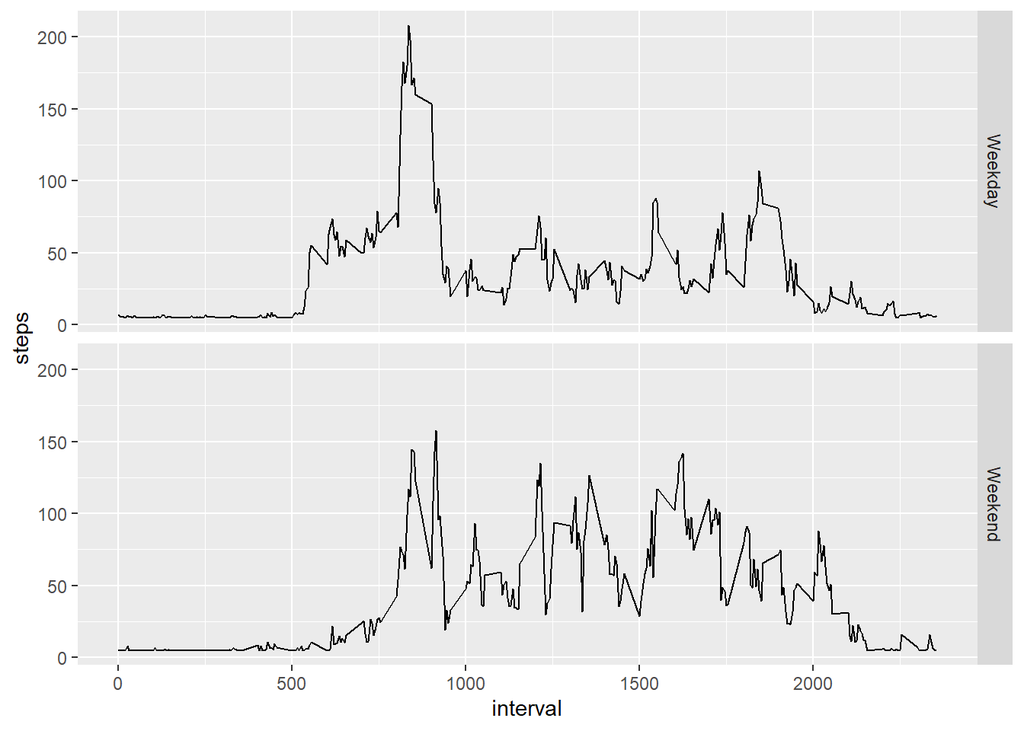

```r
datAvgStepsByDayTypeByInterval <- aggregate(steps~interval + dayType, data = datFilled, mean)
ggplot(datAvgStepsByDayTypeByInterval, aes(x = interval, y = steps)) +
  geom_line() +
  facet_grid(dayType ~ .)
```